# fracture_risk_hamza

## **Introduction**

This project aims to predict the risk of bone fractures in osteoporosis patients using demographic and clinical features — specifically age, weight, height, and bone mineral density (BMD). The dataset was balanced to address class imbalance, and features were scaled to improve model performance.

Four different machine learning approaches were explored:

1. K-Nearest Neighbours (KNN)
2. Logistic Regression
3. Random Forest
4. Support Vector Machines (SVM) with both linear and RBF kernels

```python
from google.colab import drive
drive.mount('/content/drive')

CSV_PATH = "/content/drive/MyDrive/Predicting-Fracture-Risk-in-Osteoporosis-Patients/bmd.csv"
```

**Imports**

```python
import pandas as pd
import numpy as np
import seaborn as sns
import matplotlib.pyplot as plt

from sklearn.preprocessing import MinMaxScaler
from sklearn.neighbors import KNeighborsClassifier
from sklearn.metrics import confusion_matrix, accuracy_score
from sklearn.utils import resample
from sklearn.linear_model import LogisticRegression

pd.set_option('display.max_columns', None)
```

**Load data**

```python
df = pd.read_csv(CSV_PATH)
display(df.head())
display(df.isna().sum())
```

|  | id | age | sex | fracture | weight_kg | height_cm | medication | waiting_time | bmd |
| --- | --- | --- | --- | --- | --- | --- | --- | --- | --- |
| 0 | 469 | 57.052768 | F | no fracture | 64.0 | 155.5 | Anticonvulsant | 18 | 0.8793 |
| 1 | 8724 | 75.741225 | F | no fracture | 78.0 | 162.0 | No medication | 56 | 0.7946 |
| 2 | 6736 | 70.778900 | M | no fracture | 73.0 | 170.5 | No medication | 10 | 0.9067 |
| 3 | 24180 | 78.247175 | F | no fracture | 60.0 | 148.0 | No medication | 14 | 0.7112 |
| 4 | 17072 | 54.191877 | M | no fracture | 55.0 | 161.0 | No medication | 20 | 0.7909 |

|  | 0 |
| --- | --- |
| id | 0 |
| age | 0 |
| sex | 0 |
| fracture | 0 |
| weight_kg | 0 |
| height_cm | 0 |
| medication | 0 |
| waiting_time | 0 |
| bmd | 0 |

**dtype:** int64

**Drop unneeded columns + (initial) feature/target**

```python
if 'id' in df.columns:
    df = df.drop(columns=['id'])


X_init = df[['age', 'weight_kg', 'height_cm', 'bmd']].copy()
y_init = df['fracture'].copy()

display(df.head())
```

|  | age | sex | fracture | weight_kg | height_cm | medication | waiting_time | bmd |
| --- | --- | --- | --- | --- | --- | --- | --- | --- |
| 0 | 57.052768 | F | no fracture | 64.0 | 155.5 | Anticonvulsant | 18 | 0.8793 |
| 1 | 75.741225 | F | no fracture | 78.0 | 162.0 | No medication | 56 | 0.7946 |
| 2 | 70.778900 | M | no fracture | 73.0 | 170.5 | No medication | 10 | 0.9067 |
| 3 | 78.247175 | F | no fracture | 60.0 | 148.0 | No medication | 14 | 0.7112 |
| 4 | 54.191877 | M | no fracture | 55.0 | 161.0 | No medication | 20 | 0.7909 |

**Normalise numeric features (Min–Max)**

```python
num_cols = ['age', 'weight_kg', 'height_cm', 'bmd']
scaler = MinMaxScaler()
df[num_cols] = scaler.fit_transform(df[num_cols])
display(df.head())
```

|  | age | sex | fracture | weight_kg | height_cm | medication | waiting_time | bmd |
| --- | --- | --- | --- | --- | --- | --- | --- | --- |
| 0 | 0.401187 | F | no fracture | 0.466667 | 0.385714 | Anticonvulsant | 18 | 0.494030 |
| 1 | 0.754200 | F | no fracture | 0.700000 | 0.571429 | No medication | 56 | 0.405320 |
| 2 | 0.660465 | M | no fracture | 0.616667 | 0.814286 | No medication | 10 | 0.522727 |
| 3 | 0.801536 | F | no fracture | 0.400000 | 0.171429 | No medication | 14 | 0.317972 |
| 4 | 0.347146 | M | no fracture | 0.316667 | 0.542857 | No medication | 20 | 0.401445 |

**Class balance check**

```python
print("Original class distribution:")
print(df['fracture'].value_counts())
```

```
Original class distribution:
fracture
no fracture    119
fracture        50
Name: count, dtype: int64
```

**Downsample majority class to balance**

```python
df_majority = df[df['fracture'] == 'no fracture']
df_minority = df[df['fracture'] == 'fracture']

df_majority_down = resample(
    df_majority,
    replace=False,
    n_samples=len(df_minority),
    random_state=96
)
df_bal = pd.concat([df_majority_down, df_minority]).reset_index(drop=True)

print("Balanced class distribution:")
print(df_bal['fracture'].value_counts())
display(df_bal.head())
```

```
Balanced class distribution:
fracture
no fracture    50
fracture       50
Name: count, dtype: int64
```

|  | age | sex | fracture | weight_kg | height_cm | medication | waiting_time | bmd |
| --- | --- | --- | --- | --- | --- | --- | --- | --- |
| 0 | 0.298122 | F | no fracture | 0.300000 | 0.342857 | No medication | 13 | 0.385316 |
| 1 | 0.314778 | F | no fracture | 0.383333 | 0.242857 | No medication | 6 | 0.339129 |
| 2 | 0.706773 | F | no fracture | 0.266667 | 0.314286 | No medication | 89 | 0.319648 |
| 3 | 0.775407 | M | no fracture | 0.866667 | 0.714286 | No medication | 8 | 0.622015 |
| 4 | 0.461327 | F | no fracture | 0.566667 | 0.457143 | Glucocorticoids | 8 | 0.448890 |

**One-hot encode fracture (for correlation heatmap)**

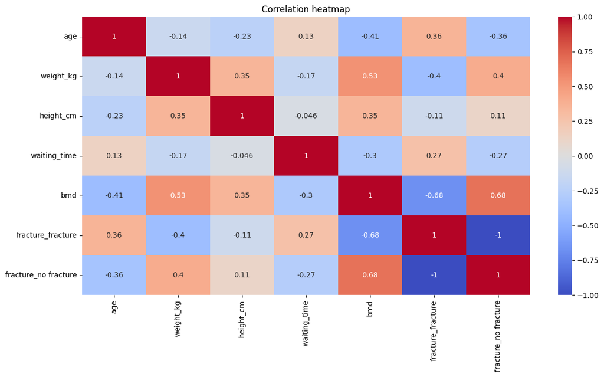

```python
df_encoded = pd.get_dummies(df_bal, columns=['fracture'])
corr = df_encoded.corr(numeric_only=True)

plt.figure(figsize=(14, 7))
sns.heatmap(corr, annot=True, cmap='coolwarm')
plt.title("Correlation heatmap")
plt.show()
```

**EDA plots**

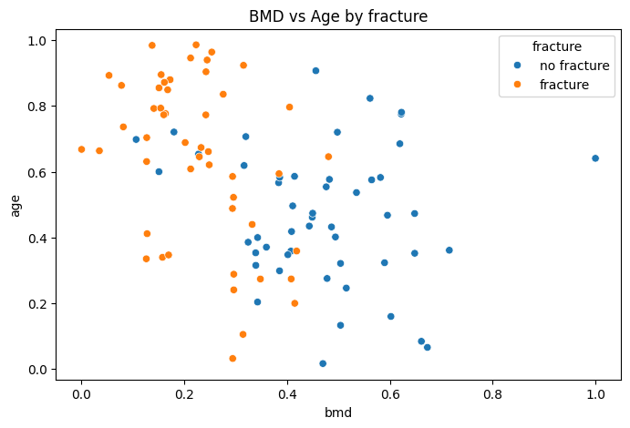

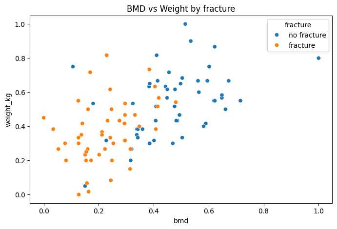

```python
# bmd vs age
plt.figure(figsize=(8,5))
sns.scatterplot(x=df_bal['bmd'], y=df_bal['age'], hue=df_bal['fracture'])
plt.title("BMD vs Age by fracture")
plt.show()

# bmd vs weight_kg
plt.figure(figsize=(8,5))
sns.scatterplot(x=df_bal['bmd'], y=df_bal['weight_kg'], hue=df_bal['fracture'])
plt.title("BMD vs Weight by fracture")
plt.show()
```

**Final X, y for modelling**

```python
X = df_bal[['age', 'weight_kg', 'height_cm', 'bmd']].copy()
y = df_bal['fracture'].copy()
```

**KNN**

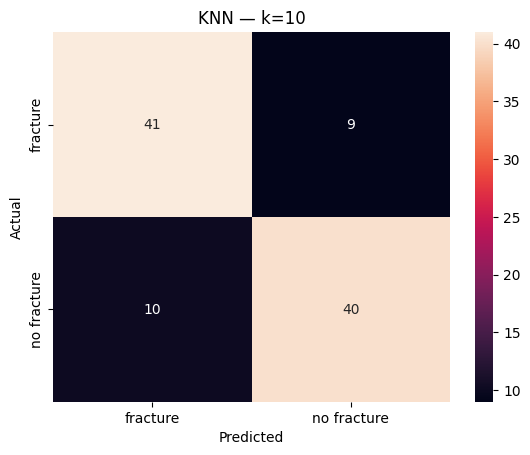

```
Accuracy for k = 10 : 0.81
Accuracy for k = 9 : 0.79
```

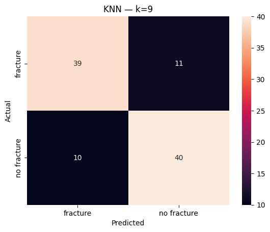

```
Accuracy for k = 11 : 0.8
```

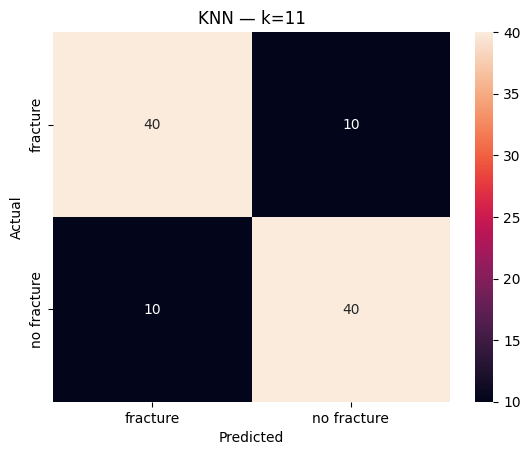

```python
# k=10
knn = KNeighborsClassifier(n_neighbors=10, metric='euclidean')
knn.fit(X, y)
y_pred = knn.predict(X)

cm = pd.crosstab(y, y_pred, rownames=['Actual'], colnames=['Predicted'])
sns.heatmap(cm, annot=True, fmt="d")
plt.title('KNN — k=10')
plt.show()

print('Accuracy for k = 10 :', accuracy_score(y, y_pred))

# k=9
knn = KNeighborsClassifier(n_neighbors=9, metric='euclidean')
knn.fit(X, y)
y_pred = knn.predict(X)

print('Accuracy for k = 9 :', accuracy_score(y, y_pred))
cm = pd.crosstab(y, y_pred, rownames=['Actual'], colnames=['Predicted'])
sns.heatmap(cm, annot=True, fmt="d")
plt.title('KNN — k=9')
plt.show()

# k=11
knn = KNeighborsClassifier(n_neighbors=11, metric='euclidean')
knn.fit(X, y)
y_pred = knn.predict(X)

print('Accuracy for k = 11 :', accuracy_score(y, y_pred))
cm = pd.crosstab(y, y_pred, rownames=['Actual'], colnames=['Predicted'])
sns.heatmap(cm, annot=True, fmt="d")
plt.title('KNN — k=11')
plt.show()
```

**Error Rate**

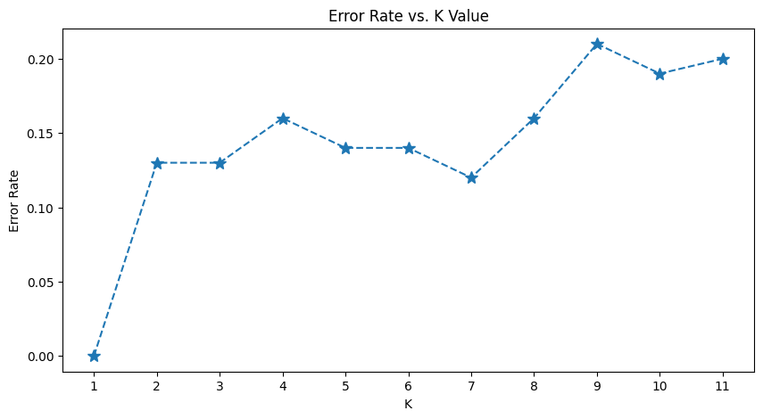

```python
error_rate = []
ks = range(1, 12)
for k in ks:
    knn = KNeighborsClassifier(n_neighbors=k, metric='euclidean')
    knn.fit(X, y)
    pred_k = knn.predict(X)
    error_rate.append(np.mean(pred_k != y))

plt.figure(figsize=(10,5))
plt.plot(list(ks), error_rate, linestyle='dashed', marker='*', markersize=10)
plt.title('Error Rate vs. K Value')
plt.xlabel('K')
plt.ylabel('Error Rate')
plt.xticks(list(ks))
plt.show()
```

```
Accuracy for k = 7 : 0.88
```

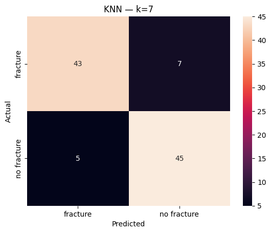

```python
knn = KNeighborsClassifier(n_neighbors=7, metric='euclidean')
knn.fit(X, y)
y_pred = knn.predict(X)

print('Accuracy for k = 7 :', accuracy_score(y, y_pred))
cm = pd.crosstab(y, y_pred, rownames=['Actual'], colnames=['Predicted'])
sns.heatmap(cm, annot=True, fmt="d")
plt.title('KNN — k=7')
plt.show()
```

```python
# Save comparison
y_pred_knn = y_pred
cm_knn = cm.copy()
acc_knn = accuracy_score(y, y_pred)

correct_knn = cm_knn.values.trace()
incorrect_knn = cm_knn.values.sum() - correct_knn

print(f"[KNN k=7] acc={acc_knn:.2f} | correct={correct_knn} | incorrect={incorrect_knn}")
```

```
[KNN k=7] acc=0.88 | correct=88 | incorrect=12
```

## **Logistic Regression**

```
Shape: (169, 9)
```

|  | id | age | sex | fracture | weight_kg | height_cm | medication | waiting_time | bmd |
| --- | --- | --- | --- | --- | --- | --- | --- | --- | --- |
| 0 | 469 | 57.052768 | F | no fracture | 64.0 | 155.5 | Anticonvulsant | 18 | 0.8793 |
| 1 | 8724 | 75.741225 | F | no fracture | 78.0 | 162.0 | No medication | 56 | 0.7946 |
| 2 | 6736 | 70.778900 | M | no fracture | 73.0 | 170.5 | No medication | 10 | 0.9067 |
| 3 | 24180 | 78.247175 | F | no fracture | 60.0 | 148.0 | No medication | 14 | 0.7112 |
| 4 | 17072 | 54.191877 | M | no fracture | 55.0 | 161.0 | No medication | 20 | 0.7909 |

```
Missing values:
 id              0
age             0
sex             0
fracture        0
weight_kg       0
height_cm       0
medication      0
waiting_time    0
bmd             0
dtype: int64
```

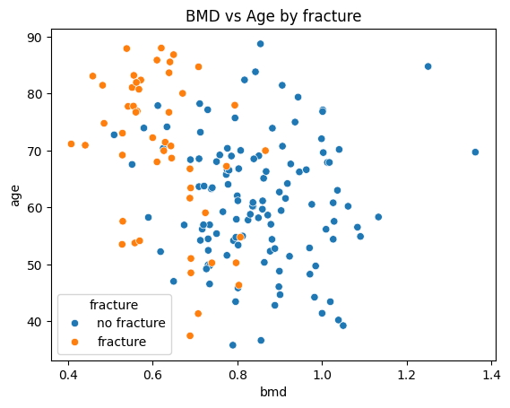

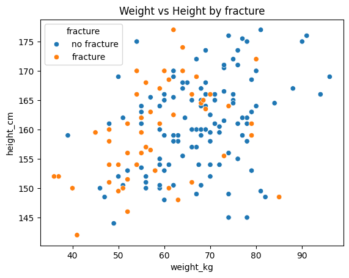

```
Original class distribution:
 fracture
no fracture    119
fracture        50
Name: count, dtype: int64

Balanced class distribution:
 fracture
no fracture    50
fracture       50
Name: count, dtype: int64
```

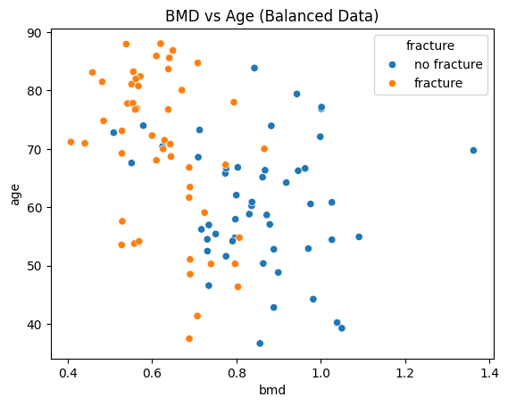

```python
from sklearn.model_selection import train_test_split, cross_val_score
from sklearn.linear_model import LogisticRegression
from sklearn import metrics
from sklearn.metrics import confusion_matrix, accuracy_score, classification_report
from sklearn.utils import resample

# Load dataset
df_lr = pd.read_csv(CSV_PATH)
print("Shape:", df_lr.shape)
display(df_lr.head())
print("\nMissing values:\n", df_lr.isna().sum())

# Quick EDA — scatterplots
sns.scatterplot(x=df_lr["bmd"], y=df_lr["age"], hue=df_lr["fracture"])
plt.title("BMD vs Age by fracture")
plt.show()

sns.scatterplot(x=df_lr["weight_kg"], y=df_lr["height_cm"], hue=df_lr["fracture"])
plt.title("Weight vs Height by fracture")
plt.show()

# Class distribution before balancing
print("\nOriginal class distribution:\n", df_lr["fracture"].value_counts())

# Downsample majority class to match minority class
df_majority = df_lr[df_lr["fracture"] == "no fracture"]
df_minority = df_lr[df_lr["fracture"] == "fracture"]

df_majority_downsampled = resample(
    df_majority, replace=False, n_samples=len(df_minority), random_state=96
)

df_bal_lr = pd.concat([df_majority_downsampled, df_minority]).reset_index(drop=True)

print("\nBalanced class distribution:\n", df_bal_lr["fracture"].value_counts())

# EDA after balancing
sns.scatterplot(x=df_bal_lr["bmd"], y=df_bal_lr["age"], hue=df_bal_lr["fracture"])
plt.title("BMD vs Age (Balanced Data)")
plt.show()
```

**Logistic Regression Model**

```python
# Features & Target
X_lr = df_bal_lr[["age", "weight_kg", "height_cm", "bmd"]]
y_lr = df_bal_lr["fracture"]

# Train/Test split (Random Sampling)
x_train, x_test, y_train, y_test = train_test_split(
    X_lr, y_lr, test_size=0.30, random_state=0, stratify=y_lr
)
print("Train size:", x_train.shape[0], " | Test size:", x_test.shape[0])

# Create Logistic Regression model (L1 penalty, liblinear solver)
model_LR = LogisticRegression(penalty="l1", solver="liblinear", max_iter=1000)
model_LR.fit(x_train, y_train)

# Show model parameters
print("Classes:", model_LR.classes_)
print("Intercept:", model_LR.intercept_)
print("Coefficients [age, weight_kg, height_cm, bmd]:")
print(model_LR.coef_)
```

```
Train size: 70  | Test size: 30
Classes: ['fracture' 'no fracture']
Intercept: [0.]
Coefficients [age, weight_kg, height_cm, bmd]:
[[-0.04736055  0.06461802 -0.02866587  5.03344623]]
```

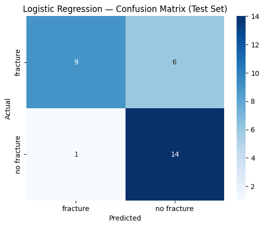

```
Test Accuracy: 0.7666666666666667

Classification Report:
               precision    recall  f1-score   support

    fracture       0.90      0.60      0.72        15
 no fracture       0.70      0.93      0.80        15

    accuracy                           0.77        30
   macro avg       0.80      0.77      0.76        30
weighted avg       0.80      0.77      0.76        30

Correct predictions: 23 | Incorrect predictions: 7
```

```python
# Predict on test set
y_pred = model_LR.predict(x_test)

# Confusion matrix
cm = pd.crosstab(y_test, y_pred, rownames=["Actual"], colnames=["Predicted"])
sns.heatmap(cm, annot=True, fmt="d", cmap="Blues")
plt.title("Logistic Regression — Confusion Matrix (Test Set)")
plt.show()

# Accuracy
acc = accuracy_score(y_test, y_pred)
print("Test Accuracy:", acc)

# Classification report
cr = classification_report(y_test, y_pred)
print("\nClassification Report:\n", cr)

# Correct vs Incorrect counts
correct = cm.values.trace()
incorrect = cm.values.sum() - correct
print(f"Correct predictions: {correct} | Incorrect predictions: {incorrect}")
```

**Cross-Validation on Balanced Dataset**

```python
cv_scores = cross_val_score(
    LogisticRegression(penalty="l1", solver="liblinear", max_iter=1000),
    X_lr, y_lr, cv=5, scoring="accuracy"
)
print("5-fold CV Accuracy Scores:", cv_scores)
print("Mean CV Accuracy:", cv_scores.mean())
```

```
5-fold CV Accuracy Scores: [0.9  0.8  0.9  0.85 0.45]
Mean CV Accuracy: 0.78
```

```python
# Comparison metrics
y_pred_lr   = y_pred
cm_lr       = cm.copy()
acc_lr      = acc
correct_lr  = correct
incorrect_lr= incorrect

print(f"[Logistic Regression] acc={acc_lr:.2f} | correct={correct_lr} | incorrect={incorrect_lr}")
```

```
[Logistic Regression] acc=0.77 | correct=23 | incorrect=7
```

## **Random Forest**

```python
from sklearn.preprocessing import MinMaxScaler
from sklearn.model_selection import train_test_split
from sklearn.ensemble import RandomForestClassifier
from sklearn.metrics import confusion_matrix, accuracy_score, classification_report
from sklearn.utils import resample

# Load
df = pd.read_csv(CSV_PATH)
print("Raw shape:", df.shape)
display(df.head())
print("\nMissing values:\n", df.isna().sum())

# Normalise numeric features (kept consistent with your earlier steps)
num_cols = ["age", "weight_kg", "height_cm", "bmd"]
scaler = MinMaxScaler()
df[num_cols] = scaler.fit_transform(df[num_cols])

# Class balance (downsample majority to minority count)
df_majority = df[df["fracture"] == "no fracture"]
df_minority = df[df["fracture"] == "fracture"]

df_majority_down = resample(
    df_majority, replace=False, n_samples=len(df_minority), random_state=96
)
df_bal = pd.concat([df_majority_down, df_minority]).reset_index(drop=True)

print("\nBalanced class distribution:\n", df_bal["fracture"].value_counts())
display(df_bal.head())

# Final X, y
X = df_bal[["age", "weight_kg", "height_cm", "bmd"]].copy()
y = df_bal["fracture"].copy()

# Train/Test split (stratify to keep 50/50 in both sets)
X_train, X_test, y_train, y_test = train_test_split(
    X, y, test_size=0.30, random_state=42, stratify=y
)
print("\nTrain size:", X_train.shape[0], " | Test size:", X_test.shape[0])
```

```
Raw shape: (169, 9)
```

|  | id | age | sex | fracture | weight_kg | height_cm | medication | waiting_time | bmd |
| --- | --- | --- | --- | --- | --- | --- | --- | --- | --- |
| 0 | 469 | 57.052768 | F | no fracture | 64.0 | 155.5 | Anticonvulsant | 18 | 0.8793 |
| 1 | 8724 | 75.741225 | F | no fracture | 78.0 | 162.0 | No medication | 56 | 0.7946 |
| 2 | 6736 | 70.778900 | M | no fracture | 73.0 | 170.5 | No medication | 10 | 0.9067 |
| 3 | 24180 | 78.247175 | F | no fracture | 60.0 | 148.0 | No medication | 14 | 0.7112 |
| 4 | 17072 | 54.191877 | M | no fracture | 55.0 | 161.0 | No medication | 20 | 0.7909 |

```
Missing values:
 id              0
age             0
sex             0
fracture        0
weight_kg       0
height_cm       0
medication      0
waiting_time    0
bmd             0
dtype: int64

Balanced class distribution:
 fracture
no fracture    50
fracture       50
Name: count, dtype: int64
```

|  | id | age | sex | fracture | weight_kg | height_cm | medication | waiting_time | bmd |
| --- | --- | --- | --- | --- | --- | --- | --- | --- | --- |
| 0 | 8896 | 0.298122 | F | no fracture | 0.300000 | 0.342857 | No medication | 13 | 0.385316 |
| 1 | 23790 | 0.314778 | F | no fracture | 0.383333 | 0.242857 | No medication | 6 | 0.339129 |
| 2 | 55 | 0.706773 | F | no fracture | 0.266667 | 0.314286 | No medication | 89 | 0.319648 |
| 3 | 5509 | 0.775407 | M | no fracture | 0.866667 | 0.714286 | No medication | 8 | 0.622015 |
| 4 | 8999 | 0.461327 | F | no fracture | 0.566667 | 0.457143 | Glucocorticoids | 8 | 0.448890 |

```
Train size: 70  | Test size: 30
```

**Random Forest (n_estimators = 10)**

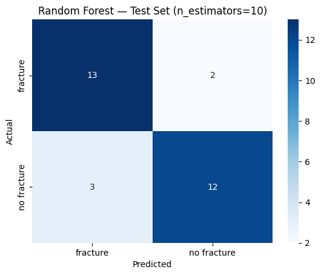

```
Test Accuracy (10 trees): 0.8333333333333334

Classification Report (10 trees):
               precision    recall  f1-score   support

    fracture       0.81      0.87      0.84        15
 no fracture       0.86      0.80      0.83        15

    accuracy                           0.83        30
   macro avg       0.83      0.83      0.83        30
weighted avg       0.83      0.83      0.83        30

Correct: 25 | Incorrect: 5
```

```python
# Train RF with 10 trees
rf10 = RandomForestClassifier(n_estimators=10, random_state=58)
rf10.fit(X_train, y_train)

# Predict on test set
y_pred10 = rf10.predict(X_test)

# Confusion matrix
cm10 = pd.crosstab(y_test, y_pred10, rownames=["Actual"], colnames=["Predicted"])
sns.heatmap(cm10, annot=True, fmt="d", cmap="Blues")
plt.title("Random Forest — Test Set (n_estimators=10)")
plt.show()

# Accuracy + classification report
acc10 = accuracy_score(y_test, y_pred10)
print("Test Accuracy (10 trees):", acc10)
print("\nClassification Report (10 trees):\n", classification_report(y_test, y_pred10))

# Quick counts
correct10 = cm10.values.trace()
incorrect10 = cm10.values.sum() - correct10
print(f"Correct: {correct10} | Incorrect: {incorrect10}")
```

**Random Forest (n_estimators = 20) + Summary**

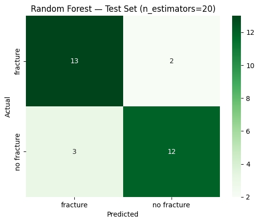

```
Test Accuracy (20 trees): 0.8333333333333334

Classification Report (20 trees):
               precision    recall  f1-score   support

    fracture       0.81      0.87      0.84        15
 no fracture       0.86      0.80      0.83        15

    accuracy                           0.83        30
   macro avg       0.83      0.83      0.83        30
weighted avg       0.83      0.83      0.83        30

Correct: 25 | Incorrect: 5
```

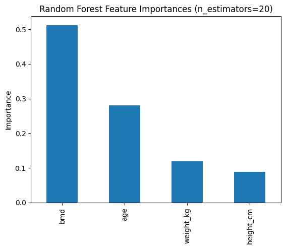

```
 Random Forest Summary
10 trees -> accuracy: 0.83 | correct=25 | incorrect=5
20 trees -> accuracy: 0.83 | correct=25 | incorrect=5
```

```python
# Train RF with 20 trees
rf20 = RandomForestClassifier(n_estimators=20, random_state=52)
rf20.fit(X_train, y_train)

# Predict on test set
y_pred20 = rf20.predict(X_test)

# Confusion matrix
cm20 = pd.crosstab(y_test, y_pred20, rownames=["Actual"], colnames=["Predicted"])
sns.heatmap(cm20, annot=True, fmt="d", cmap="Greens")
plt.title("Random Forest — Test Set (n_estimators=20)")
plt.show()

# Accuracy + classification report
acc20 = accuracy_score(y_test, y_pred20)
print("Test Accuracy (20 trees):", acc20)
print("\nClassification Report (20 trees):\n", classification_report(y_test, y_pred20))

# Quick counts
correct20 = cm20.values.trace()
incorrect20 = cm20.values.sum() - correct20
print(f"Correct: {correct20} | Incorrect: {incorrect20}")

# Feature importance (from the 20-tree model)
importances = pd.Series(rf20.feature_importances_, index=X_train.columns).sort_values(ascending=False)
ax = importances.plot(kind="bar")
plt.title("Random Forest Feature Importances (n_estimators=20)")
plt.ylabel("Importance")
plt.show()

# Summary
print("\n Random Forest Summary")
print(f"10 trees -> accuracy: {acc10:.2f} | correct={correct10} | incorrect={incorrect10}")
print(f"20 trees -> accuracy: {acc20:.2f} | correct={correct20} | incorrect={incorrect20}")
```

```python
acc_rf10       = acc10
correct_rf10   = correct10
incorrect_rf10 = incorrect10
cm_rf10        = cm10.copy()

# Comparison metrics for Random Forest (20 trees)
acc_rf20       = acc20
correct_rf20   = correct20
incorrect_rf20 = incorrect20
cm_rf20        = cm20.copy()
```

### **SVM**

```python
from sklearn.preprocessing import MinMaxScaler
from sklearn.model_selection import train_test_split
from sklearn.utils import resample
from sklearn.metrics import confusion_matrix, accuracy_score, classification_report
from sklearn import svm

# Load
df = pd.read_csv(CSV_PATH)
print("Raw shape:", df.shape)
display(df.head())
print("\nMissing values:\n", df.isna().sum())

# Normalise numeric features
num_cols = ["age", "weight_kg", "height_cm", "bmd"]
scaler = MinMaxScaler()
df[num_cols] = scaler.fit_transform(df[num_cols])

# Balance (downsample majority to match minority)
df_majority = df[df["fracture"] == "no fracture"]
df_minority = df[df["fracture"] == "fracture"]

df_majority_down = resample(
    df_majority, replace=False, n_samples=len(df_minority), random_state=96
)
df_bal = pd.concat([df_majority_down, df_minority]).reset_index(drop=True)

print("\nBalanced class distribution:\n", df_bal["fracture"].value_counts())

# Final features/target
X = df_bal[["age", "weight_kg", "height_cm", "bmd"]].copy()
y = df_bal["fracture"].copy()

# Train/Test split (hold-out)
X_train, X_test, y_train, y_test = train_test_split(
    X, y, test_size=0.30, random_state=42, stratify=y
)
print("Train size:", X_train.shape[0], " | Test size:", X_test.shape[0])
```

```
Raw shape: (169, 9)
```

|  | id | age | sex | fracture | weight_kg | height_cm | medication | waiting_time | bmd |
| --- | --- | --- | --- | --- | --- | --- | --- | --- | --- |
| 0 | 469 | 57.052768 | F | no fracture | 64.0 | 155.5 | Anticonvulsant | 18 | 0.8793 |
| 1 | 8724 | 75.741225 | F | no fracture | 78.0 | 162.0 | No medication | 56 | 0.7946 |
| 2 | 6736 | 70.778900 | M | no fracture | 73.0 | 170.5 | No medication | 10 | 0.9067 |
| 3 | 24180 | 78.247175 | F | no fracture | 60.0 | 148.0 | No medication | 14 | 0.7112 |
| 4 | 17072 | 54.191877 | M | no fracture | 55.0 | 161.0 | No medication | 20 | 0.7909 |

```
Missing values:
 id              0
age             0
sex             0
fracture        0
weight_kg       0
height_cm       0
medication      0
waiting_time    0
bmd             0
dtype: int64

Balanced class distribution:
 fracture
no fracture    50
fracture       50
Name: count, dtype: int64
Train size: 70  | Test size: 30
```

**Linear & RBF SVM**

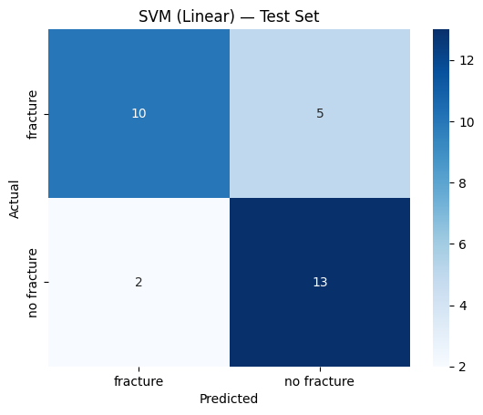

```
Test Accuracy (Linear): 0.7666666666666667

Classification Report (Linear):
               precision    recall  f1-score   support

    fracture       0.83      0.67      0.74        15
 no fracture       0.72      0.87      0.79        15

    accuracy                           0.77        30
   macro avg       0.78      0.77      0.76        30
weighted avg       0.78      0.77      0.76        30
```

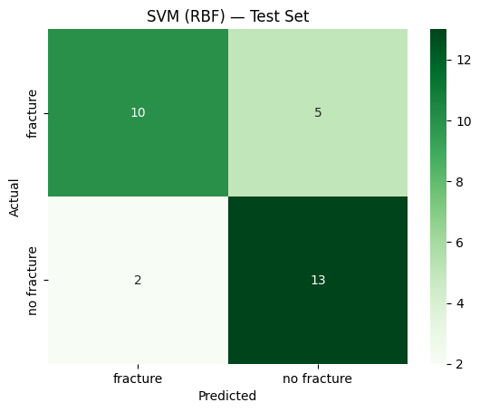

```
Test Accuracy (RBF): 0.7666666666666667

Classification Report (RBF):
               precision    recall  f1-score   support

    fracture       0.83      0.67      0.74        15
 no fracture       0.72      0.87      0.79        15

    accuracy                           0.77        30
   macro avg       0.78      0.77      0.76        30
weighted avg       0.78      0.77      0.76        30


=== SVM (hold-out test) Summary ===
Linear -> accuracy: 0.77 | correct=23 | incorrect=7
RBF    -> accuracy: 0.77 | correct=23 | incorrect=7
```

```python
# Linear SVM
linear_svm = svm.SVC(kernel="linear", C=1.0)
linear_svm.fit(X_train, y_train)

y_pred_lin = linear_svm.predict(X_test)

cm_lin = pd.crosstab(y_test, y_pred_lin, rownames=["Actual"], colnames=["Predicted"])
sns.heatmap(cm_lin, annot=True, fmt="d", cmap="Blues")
plt.title("SVM (Linear) — Test Set")
plt.show()

acc_lin = accuracy_score(y_test, y_pred_lin)
print("Test Accuracy (Linear):", acc_lin)
print("\nClassification Report (Linear):\n", classification_report(y_test, y_pred_lin))

# RBF SVM
rbf_svm = svm.SVC(kernel="rbf", gamma=0.7, C=1.0)
rbf_svm.fit(X_train, y_train)

y_pred_rbf = rbf_svm.predict(X_test)

cm_rbf = pd.crosstab(y_test, y_pred_rbf, rownames=["Actual"], colnames=["Predicted"])
sns.heatmap(cm_rbf, annot=True, fmt="d", cmap="Greens")
plt.title("SVM (RBF) — Test Set")
plt.show()

acc_rbf = accuracy_score(y_test, y_pred_rbf)
print("Test Accuracy (RBF):", acc_rbf)
print("\nClassification Report (RBF):\n", classification_report(y_test, y_pred_rbf))

# Summary
correct_lin = cm_lin.values.trace(); incorrect_lin = cm_lin.values.sum() - correct_lin
correct_rbf = cm_rbf.values.trace(); incorrect_rbf = cm_rbf.values.sum() - correct_rbf

print("\n=== SVM (hold-out test) Summary ===")
print(f"Linear -> accuracy: {acc_lin:.2f} | correct={correct_lin} | incorrect={incorrect_lin}")
print(f"RBF    -> accuracy: {acc_rbf:.2f} | correct={correct_rbf} | incorrect={incorrect_rbf}")
```

**RBF SVM — GridSearchCV on training set (tune C & gamma)**

```
Best params: {'C': 10, 'gamma': 0.3}
Best CV accuracy: 0.8428571428571429
```

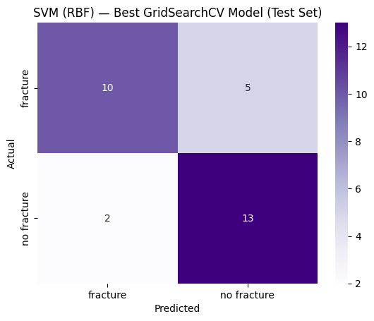

```
Test Accuracy (best RBF): 0.7666666666666667

Classification Report (best RBF):
               precision    recall  f1-score   support

    fracture       0.83      0.67      0.74        15
 no fracture       0.72      0.87      0.79        15

    accuracy                           0.77        30
   macro avg       0.78      0.77      0.76        30
weighted avg       0.78      0.77      0.76        30
```

```python
from sklearn.model_selection import GridSearchCV, StratifiedKFold
from sklearn import svm
from sklearn.metrics import confusion_matrix, accuracy_score, classification_report
import pandas as pd
import seaborn as sns
import matplotlib.pyplot as plt

# Grid (kept small enough to run fast but still useful)
param_grid = {
    "C": [0.1, 1, 3, 10, 30, 100],
    "gamma": ["scale", 0.01, 0.03, 0.1, 0.3, 1.0]
}

cv = StratifiedKFold(n_splits=5, shuffle=True, random_state=42)
rbf = svm.SVC(kernel="rbf")

grid = GridSearchCV(
    estimator=rbf,
    param_grid=param_grid,
    scoring="accuracy",
    cv=cv,
    n_jobs=-1,
    verbose=0,
    refit=True,
)

grid.fit(X_train, y_train)

print("Best params:", grid.best_params_)
print("Best CV accuracy:", grid.best_score_)

# Evaluate best model on hold-out test set
best_rbf = grid.best_estimator_
y_pred_gs = best_rbf.predict(X_test)

cm = pd.crosstab(y_test, y_pred_gs, rownames=["Actual"], colnames=["Predicted"])
sns.heatmap(cm, annot=True, fmt="d", cmap="Purples")
plt.title("SVM (RBF) — Best GridSearchCV Model (Test Set)")
plt.show()

acc = accuracy_score(y_test, y_pred_gs)
print("Test Accuracy (best RBF):", acc)
print("\nClassification Report (best RBF):\n", classification_report(y_test, y_pred_gs))
```

**Visualise CV scores heatmap**

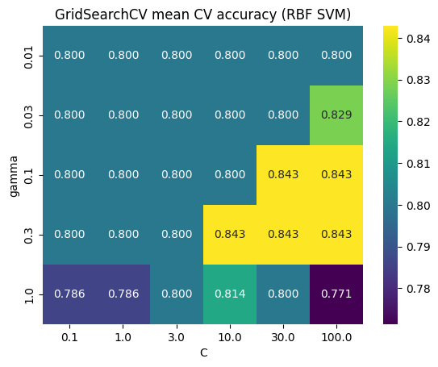

```python
# Build a pivot table for mean CV accuracy (only numeric gamma values)
cv_results = pd.DataFrame(grid.cv_results_)
plot_df = cv_results[cv_results["param_gamma"] != "scale"].copy()
plot_df["C"] = plot_df["param_C"].astype(float)
plot_df["gamma"] = plot_df["param_gamma"].astype(float)

pivot = plot_df.pivot_table(
    index="gamma", columns="C", values="mean_test_score"
).sort_index(ascending=True)

sns.heatmap(pivot, annot=True, fmt=".3f", cmap="viridis")
plt.title("GridSearchCV mean CV accuracy (RBF SVM)")
plt.ylabel("gamma")
plt.xlabel("C")
plt.show()
```

```python
# Comparison metrics for SVM (Linear)
cm_svm_lin       = cm_lin.copy()
acc_svm_lin      = acc_lin
correct_svm_lin  = correct_lin
incorrect_svm_lin= incorrect_lin

# Comparison metrics for SVM (RBF)
cm_svm_rbf       = cm_rbf.copy()
acc_svm_rbf      = acc_rbf
correct_svm_rbf  = correct_rbf
incorrect_svm_rbf= incorrect_rbf

# Comparison metrics for SVM (Best RBF GridSearchCV)
cm_svm_gs        = cm.copy()
acc_svm_gs       = acc
correct_svm_gs   = cm_svm_gs.values.trace()
incorrect_svm_gs = cm_svm_gs.values.sum() - correct_svm_gs
```

```
Model Comparison
```

|  | Model | Accuracy | Correct | Incorrect |
| --- | --- | --- | --- | --- |
| 0 | KNN (k=7) | 0.880000 | 88 | 12 |
| 1 | Random Forest (10 trees) | 0.833333 | 25 | 5 |
| 2 | Random Forest (20 trees) | 0.833333 | 25 | 5 |
| 3 | Logistic Regression (L1, liblinear) | 0.766667 | 23 | 7 |
| 4 | SVM (Linear, C=1) | 0.766667 | 23 | 7 |
| 5 | SVM (RBF, C=1, γ=0.7) | 0.766667 | 23 | 7 |
| 6 | SVM (RBF, GridSearch best) | 0.766667 | 23 | 7 |

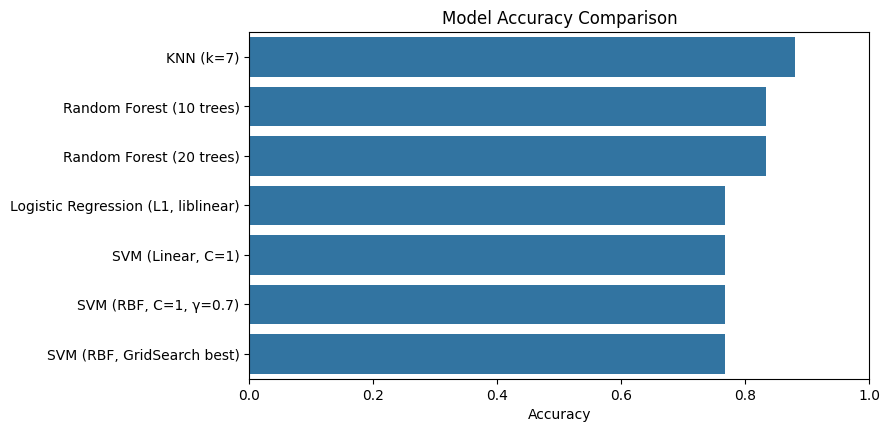

```python
# Final Model Comparison
import pandas as pd
import seaborn as sns
import matplotlib.pyplot as plt

rows = []

def add_row(name, acc_var, cm_var=None, correct_var=None, incorrect_var=None):
    """Add a model row if its accuracy variable exists."""
    try:
        acc = globals()[acc_var]
    except KeyError:
        return  # model not run / variable not defined -> skip

    # correct/incorrect: prefer provided vars, else compute from cm if available
    if correct_var and incorrect_var and correct_var in globals() and incorrect_var in globals():
        correct = globals()[correct_var]
        incorrect = globals()[incorrect_var]
    elif cm_var and cm_var in globals():
        cm = globals()[cm_var]
        correct = cm.values.trace()
        incorrect = cm.values.sum() - correct
    else:
        correct = None
        incorrect = None

    rows.append({
        "Model": name,
        "Accuracy": float(acc),
        "Correct": correct,
        "Incorrect": incorrect
    })

# KNN (k=7) — from your KNN block
add_row("KNN (k=7)", "acc_knn", cm_var="cm_knn", correct_var="correct_knn", incorrect_var="incorrect_knn")

# Logistic Regression
add_row("Logistic Regression (L1, liblinear)", "acc_lr", cm_var="cm_lr", correct_var="correct_lr", incorrect_var="incorrect_lr")

# Random Forest
add_row("Random Forest (10 trees)", "acc_rf10", cm_var="cm_rf10", correct_var="correct_rf10", incorrect_var="incorrect_rf10")
add_row("Random Forest (20 trees)", "acc_rf20", cm_var="cm_rf20", correct_var="correct_rf20", incorrect_var="incorrect_rf20")

# SVM
add_row("SVM (Linear, C=1)", "acc_svm_lin", cm_var="cm_svm_lin", correct_var="correct_svm_lin", incorrect_var="incorrect_svm_lin")
add_row("SVM (RBF, C=1, γ=0.7)", "acc_svm_rbf", cm_var="cm_svm_rbf", correct_var="correct_svm_rbf", incorrect_var="incorrect_svm_rbf")
add_row("SVM (RBF, GridSearch best)", "acc_svm_gs", cm_var="cm_svm_gs", correct_var="correct_svm_gs", incorrect_var="incorrect_svm_gs")

# Build & show table
df_results = pd.DataFrame(rows)
if df_results.empty:
    raise RuntimeError("No model metrics found. Make sure you ran the model cells and the 'save comparison metrics' lines.")

df_results = df_results.sort_values("Accuracy", ascending=False).reset_index(drop=True)
print("Model Comparison")
display(df_results)

# Plot
plt.figure(figsize=(8, 4.5))
sns.barplot(data=df_results, x="Accuracy", y="Model")
plt.title("Model Accuracy Comparison")
plt.xlim(0, 1)
plt.xlabel("Accuracy")
plt.ylabel("")
plt.show()
```

## **Model Performance Summary**

Accuracy: 88% (88 correct, 12 incorrect predictions)

**2. Strong performers — Random Forest (10 and 20 trees)**

Accuracy: 83.3% for both configurations.

Increasing trees from 10 to 20 did not yield improvement, indicating stability of the ensemble performance.

Feature importance analysis showed BMD and Age as the most predictive variables.

**3. Moderate performers — Logistic Regression & SVMs**

Accuracy: 76.7% across Logistic Regression, SVM Linear, SVM RBF, and SVM with GridSearch.

These models likely underperformed due to the relatively small feature set and possible nonlinear relationships in the data that weren’t fully captured by the chosen kernels or regularisation strength.

## **Key Insights**

**Tree models:** Offer interpretability via feature importance and performed consistently well.

**Linear models:** Struggled slightly, possibly due to the nonlinear interaction of BMD with other variables.

```python
!pip -q install nbconvert

!jupyter nbconvert --to html "/content/drive/MyDrive/Predicting-Fracture-Risk-in-Osteoporosis-Patients/fracture_risk_hamza.ipynb" --output osteoporosis.html

from google.colab import files
files.download('osteoporosis.html')
```

```
[NbConvertApp] Converting notebook /content/drive/MyDrive/Predicting-Fracture-Risk-in-Osteoporosis-Patients/fracture_risk_hamza.ipynb to html
[NbConvertApp] WARNING | Alternative text is missing on 20 image(s).
[NbConvertApp] Writing 1255887 bytes to /content/drive/MyDrive/Predicting-Fracture-Risk-in-Osteoporosis-Patients/fracture_risk_hamza.html
```

[output not shown]